# Optimal Treatment Analysis

## Outcome Variable

**Outcome Variable:** haz

## Predictor Variables

**Intervention Variable:** safeh20

**Adjustment Set:**

- arm
- sex
- W_mage
- meducyrs
- feducyrs
- hhwealth_quart
- hfoodsec
- W_mhtcm
- W_nrooms
- W_nchldlt5
- W_parity
- impfloor
- impsan
- delta_W_mage
- delta_meducyrs
- delta_feducyrs
- delta_hhwealth_quart
- delta_hfoodsec
- delta_W_mhtcm
- delta_W_nrooms
- delta_W_nchldlt5
- delta_W_parity
- delta_impfloor
- delta_impsan

## Stratifying Variables

The analysis was stratified on these variable(s):

- agecat
- studyid
- country

## Data Summary

| agecat | studyid | country | safeh20 | n_cell | n |
| --- | --- | --- | --- | --- | --- |
| Birth | ki0047075b-MAL-ED | BANGLADESH | 1 | 0 | 234 |
| Birth | ki0047075b-MAL-ED | BANGLADESH | 0 | 234 | 234 |
| Birth | ki0047075b-MAL-ED | BRAZIL | 1 | 0 | 124 |
| Birth | ki0047075b-MAL-ED | BRAZIL | 0 | 124 | 124 |
| Birth | ki0047075b-MAL-ED | INDIA | 1 | 0 | 191 |
| Birth | ki0047075b-MAL-ED | INDIA | 0 | 191 | 191 |
| Birth | ki0047075b-MAL-ED | NEPAL | 1 | 1 | 168 |
| Birth | ki0047075b-MAL-ED | NEPAL | 0 | 167 | 168 |
| Birth | ki0047075b-MAL-ED | PERU | 1 | 9 | 247 |
| Birth | ki0047075b-MAL-ED | PERU | 0 | 238 | 247 |
| Birth | ki0047075b-MAL-ED | SOUTH AFRICA | 1 | 33 | 216 |
| Birth | ki0047075b-MAL-ED | SOUTH AFRICA | 0 | 183 | 216 |
| Birth | ki0047075b-MAL-ED | TANZANIA, UNITED REPUBLIC OF | 1 | 79 | 118 |
| Birth | ki0047075b-MAL-ED | TANZANIA, UNITED REPUBLIC OF | 0 | 39 | 118 |
| Birth | ki1017093-NIH-Birth | BANGLADESH | 1 | 28 | 28 |
| Birth | ki1017093-NIH-Birth | BANGLADESH | 0 | 0 | 28 |
| Birth | ki1017093c-NIH-Crypto | BANGLADESH | 1 | 27 | 27 |
| Birth | ki1017093c-NIH-Crypto | BANGLADESH | 0 | 0 | 27 |
| Birth | kiGH5241-JiVitA-3 | BANGLADESH | 1 | 19558 | 19593 |
| Birth | kiGH5241-JiVitA-3 | BANGLADESH | 0 | 35 | 19593 |
| Birth | kiGH5241-JiVitA-4 | BANGLADESH | 1 | 822 | 822 |
| Birth | kiGH5241-JiVitA-4 | BANGLADESH | 0 | 0 | 822 |
| 6 months | ki0047075b-MAL-ED | BANGLADESH | 1 | 0 | 240 |
| 6 months | ki0047075b-MAL-ED | BANGLADESH | 0 | 240 | 240 |
| 6 months | ki0047075b-MAL-ED | BRAZIL | 1 | 0 | 142 |
| 6 months | ki0047075b-MAL-ED | BRAZIL | 0 | 142 | 142 |
| 6 months | ki0047075b-MAL-ED | INDIA | 1 | 0 | 235 |
| 6 months | ki0047075b-MAL-ED | INDIA | 0 | 235 | 235 |
| 6 months | ki0047075b-MAL-ED | NEPAL | 1 | 1 | 233 |
| 6 months | ki0047075b-MAL-ED | NEPAL | 0 | 232 | 233 |
| 6 months | ki0047075b-MAL-ED | PERU | 1 | 11 | 259 |
| 6 months | ki0047075b-MAL-ED | PERU | 0 | 248 | 259 |
| 6 months | ki0047075b-MAL-ED | SOUTH AFRICA | 1 | 37 | 248 |
| 6 months | ki0047075b-MAL-ED | SOUTH AFRICA | 0 | 211 | 248 |
| 6 months | ki0047075b-MAL-ED | TANZANIA, UNITED REPUBLIC OF | 1 | 168 | 246 |
| 6 months | ki0047075b-MAL-ED | TANZANIA, UNITED REPUBLIC OF | 0 | 78 | 246 |
| 6 months | ki1000304b-SAS-FoodSuppl | INDIA | 1 | 380 | 380 |
| 6 months | ki1000304b-SAS-FoodSuppl | INDIA | 0 | 0 | 380 |
| 6 months | ki1017093-NIH-Birth | BANGLADESH | 1 | 535 | 537 |
| 6 months | ki1017093-NIH-Birth | BANGLADESH | 0 | 2 | 537 |
| 6 months | ki1017093b-PROVIDE | BANGLADESH | 1 | 581 | 581 |
| 6 months | ki1017093b-PROVIDE | BANGLADESH | 0 | 0 | 581 |
| 6 months | ki1017093c-NIH-Crypto | BANGLADESH | 1 | 715 | 715 |
| 6 months | ki1017093c-NIH-Crypto | BANGLADESH | 0 | 0 | 715 |
| 6 months | ki1114097-CONTENT | PERU | 1 | 54 | 57 |
| 6 months | ki1114097-CONTENT | PERU | 0 | 3 | 57 |
| 6 months | ki1148112-LCNI-5 | MALAWI | 1 | 672 | 816 |
| 6 months | ki1148112-LCNI-5 | MALAWI | 0 | 144 | 816 |
| 6 months | kiGH5241-JiVitA-3 | BANGLADESH | 1 | 16783 | 16803 |
| 6 months | kiGH5241-JiVitA-3 | BANGLADESH | 0 | 20 | 16803 |
| 6 months | kiGH5241-JiVitA-4 | BANGLADESH | 1 | 4824 | 4825 |
| 6 months | kiGH5241-JiVitA-4 | BANGLADESH | 0 | 1 | 4825 |
| 24 months | ki0047075b-MAL-ED | BANGLADESH | 1 | 0 | 212 |
| 24 months | ki0047075b-MAL-ED | BANGLADESH | 0 | 212 | 212 |
| 24 months | ki0047075b-MAL-ED | BRAZIL | 1 | 0 | 113 |
| 24 months | ki0047075b-MAL-ED | BRAZIL | 0 | 113 | 113 |
| 24 months | ki0047075b-MAL-ED | INDIA | 1 | 0 | 227 |
| 24 months | ki0047075b-MAL-ED | INDIA | 0 | 227 | 227 |
| 24 months | ki0047075b-MAL-ED | NEPAL | 1 | 1 | 226 |
| 24 months | ki0047075b-MAL-ED | NEPAL | 0 | 225 | 226 |
| 24 months | ki0047075b-MAL-ED | PERU | 1 | 7 | 193 |
| 24 months | ki0047075b-MAL-ED | PERU | 0 | 186 | 193 |
| 24 months | ki0047075b-MAL-ED | SOUTH AFRICA | 1 | 34 | 237 |
| 24 months | ki0047075b-MAL-ED | SOUTH AFRICA | 0 | 203 | 237 |
| 24 months | ki0047075b-MAL-ED | TANZANIA, UNITED REPUBLIC OF | 1 | 145 | 213 |
| 24 months | ki0047075b-MAL-ED | TANZANIA, UNITED REPUBLIC OF | 0 | 68 | 213 |
| 24 months | ki1017093-NIH-Birth | BANGLADESH | 1 | 427 | 429 |
| 24 months | ki1017093-NIH-Birth | BANGLADESH | 0 | 2 | 429 |
| 24 months | ki1017093b-PROVIDE | BANGLADESH | 1 | 576 | 576 |
| 24 months | ki1017093b-PROVIDE | BANGLADESH | 0 | 0 | 576 |
| 24 months | ki1017093c-NIH-Crypto | BANGLADESH | 1 | 514 | 514 |
| 24 months | ki1017093c-NIH-Crypto | BANGLADESH | 0 | 0 | 514 |
| 24 months | ki1114097-CONTENT | PERU | 1 | 45 | 48 |
| 24 months | ki1114097-CONTENT | PERU | 0 | 3 | 48 |
| 24 months | ki1148112-LCNI-5 | MALAWI | 1 | 475 | 574 |
| 24 months | ki1148112-LCNI-5 | MALAWI | 0 | 99 | 574 |
| 24 months | kiGH5241-JiVitA-3 | BANGLADESH | 1 | 8612 | 8623 |
| 24 months | kiGH5241-JiVitA-3 | BANGLADESH | 0 | 11 | 8623 |
| 24 months | kiGH5241-JiVitA-4 | BANGLADESH | 1 | 4746 | 4747 |
| 24 months | kiGH5241-JiVitA-4 | BANGLADESH | 0 | 1 | 4747 |

The following strata were considered:

- agecat: 24 months, studyid: ki0047075b-MAL-ED, country: BANGLADESH
- agecat: 24 months, studyid: ki0047075b-MAL-ED, country: BRAZIL
- agecat: 24 months, studyid: ki0047075b-MAL-ED, country: INDIA
- agecat: 24 months, studyid: ki0047075b-MAL-ED, country: NEPAL
- agecat: 24 months, studyid: ki0047075b-MAL-ED, country: PERU
- agecat: 24 months, studyid: ki0047075b-MAL-ED, country: SOUTH AFRICA
- agecat: 24 months, studyid: ki0047075b-MAL-ED, country: TANZANIA, UNITED REPUBLIC OF
- agecat: 24 months, studyid: ki1017093-NIH-Birth, country: BANGLADESH
- agecat: 24 months, studyid: ki1017093b-PROVIDE, country: BANGLADESH
- agecat: 24 months, studyid: ki1017093c-NIH-Crypto, country: BANGLADESH
- agecat: 24 months, studyid: ki1114097-CONTENT, country: PERU
- agecat: 24 months, studyid: ki1148112-LCNI-5, country: MALAWI
- agecat: 24 months, studyid: kiGH5241-JiVitA-3, country: BANGLADESH
- agecat: 24 months, studyid: kiGH5241-JiVitA-4, country: BANGLADESH
- agecat: 6 months, studyid: ki0047075b-MAL-ED, country: BANGLADESH
- agecat: 6 months, studyid: ki0047075b-MAL-ED, country: BRAZIL
- agecat: 6 months, studyid: ki0047075b-MAL-ED, country: INDIA
- agecat: 6 months, studyid: ki0047075b-MAL-ED, country: NEPAL
- agecat: 6 months, studyid: ki0047075b-MAL-ED, country: PERU
- agecat: 6 months, studyid: ki0047075b-MAL-ED, country: SOUTH AFRICA
- agecat: 6 months, studyid: ki0047075b-MAL-ED, country: TANZANIA, UNITED REPUBLIC OF
- agecat: 6 months, studyid: ki1000304b-SAS-FoodSuppl, country: INDIA
- agecat: 6 months, studyid: ki1017093-NIH-Birth, country: BANGLADESH
- agecat: 6 months, studyid: ki1017093b-PROVIDE, country: BANGLADESH
- agecat: 6 months, studyid: ki1017093c-NIH-Crypto, country: BANGLADESH
- agecat: 6 months, studyid: ki1114097-CONTENT, country: PERU
- agecat: 6 months, studyid: ki1148112-LCNI-5, country: MALAWI
- agecat: 6 months, studyid: kiGH5241-JiVitA-3, country: BANGLADESH
- agecat: 6 months, studyid: kiGH5241-JiVitA-4, country: BANGLADESH
- agecat: Birth, studyid: ki0047075b-MAL-ED, country: BANGLADESH
- agecat: Birth, studyid: ki0047075b-MAL-ED, country: BRAZIL
- agecat: Birth, studyid: ki0047075b-MAL-ED, country: INDIA
- agecat: Birth, studyid: ki0047075b-MAL-ED, country: NEPAL
- agecat: Birth, studyid: ki0047075b-MAL-ED, country: PERU
- agecat: Birth, studyid: ki0047075b-MAL-ED, country: SOUTH AFRICA
- agecat: Birth, studyid: ki0047075b-MAL-ED, country: TANZANIA, UNITED REPUBLIC OF
- agecat: Birth, studyid: ki1017093-NIH-Birth, country: BANGLADESH
- agecat: Birth, studyid: ki1017093c-NIH-Crypto, country: BANGLADESH
- agecat: Birth, studyid: kiGH5241-JiVitA-3, country: BANGLADESH
- agecat: Birth, studyid: kiGH5241-JiVitA-4, country: BANGLADESH

### Dropped Strata

- agecat: Birth, studyid: ki0047075b-MAL-ED, country: BANGLADESH
- agecat: Birth, studyid: ki0047075b-MAL-ED, country: BRAZIL
- agecat: Birth, studyid: ki0047075b-MAL-ED, country: INDIA
- agecat: Birth, studyid: ki0047075b-MAL-ED, country: NEPAL
- agecat: Birth, studyid: ki1017093-NIH-Birth, country: BANGLADESH
- agecat: Birth, studyid: ki1017093c-NIH-Crypto, country: BANGLADESH
- agecat: Birth, studyid: kiGH5241-JiVitA-4, country: BANGLADESH
- agecat: 6 months, studyid: ki0047075b-MAL-ED, country: BANGLADESH
- agecat: 6 months, studyid: ki0047075b-MAL-ED, country: BRAZIL
- agecat: 6 months, studyid: ki0047075b-MAL-ED, country: INDIA
- agecat: 6 months, studyid: ki0047075b-MAL-ED, country: NEPAL
- agecat: 6 months, studyid: ki1000304b-SAS-FoodSuppl, country: INDIA
- agecat: 6 months, studyid: ki1017093-NIH-Birth, country: BANGLADESH
- agecat: 6 months, studyid: ki1017093b-PROVIDE, country: BANGLADESH
- agecat: 6 months, studyid: ki1017093c-NIH-Crypto, country: BANGLADESH
- agecat: 6 months, studyid: ki1114097-CONTENT, country: PERU
- agecat: 6 months, studyid: kiGH5241-JiVitA-4, country: BANGLADESH
- agecat: 24 months, studyid: ki0047075b-MAL-ED, country: BANGLADESH
- agecat: 24 months, studyid: ki0047075b-MAL-ED, country: BRAZIL
- agecat: 24 months, studyid: ki0047075b-MAL-ED, country: INDIA
- agecat: 24 months, studyid: ki0047075b-MAL-ED, country: NEPAL
- agecat: 24 months, studyid: ki1017093-NIH-Birth, country: BANGLADESH
- agecat: 24 months, studyid: ki1017093b-PROVIDE, country: BANGLADESH
- agecat: 24 months, studyid: ki1017093c-NIH-Crypto, country: BANGLADESH
- agecat: 24 months, studyid: ki1114097-CONTENT, country: PERU
- agecat: 24 months, studyid: kiGH5241-JiVitA-4, country: BANGLADESH

## Methods Detail

We’re interested in the causal parameters $E[Y_a]$ for all values of $a \in \mathcal{A}$. These parameters represent the mean outcome if, possibly contrary to fact, we intervened to set all units to have $A=a$. Under the randomization and positivity assumptions, these are identified by the statistical parameters $\psi_a=E_W[E_{Y|A,W}(Y|A=a,W)]$. In addition, we’re interested in the mean of $Y$, $E[Y]$ under no intervention (the observed mean). We will estimate these parameters by using SuperLearner to fit the relevant likelihood factors – $E_{Y|A,W}(Y|A=a,W)$ and $p(A=a|W)$, and then updating our likelihood fit using a joint TMLE.

For unadjusted analyses ($W=\{\}$), initial likelihoods were estimated using Lrnr_glm to estimate the simple $E(Y|A)$ and Lrnr_mean to estimate $p(A)$. For adjusted analyses, a small library containing Lrnr_glmnet, Lrnr_xgboost, and Lrnr_mean was used.

Having estimated these parameters, we will then use the delta method to estimate relative risks and attributable risks relative to a prespecified baseline level of $A$.

# Results Detail

## Results Plots

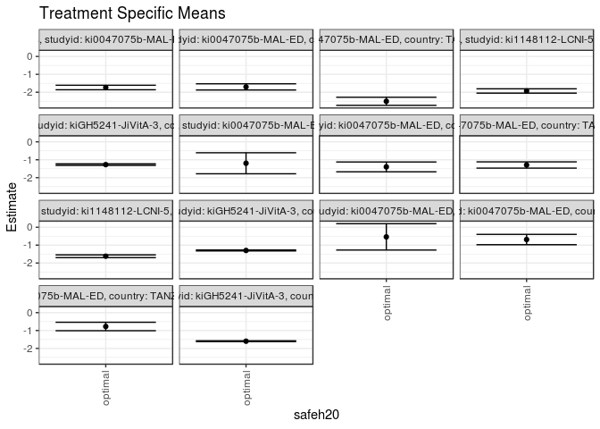

## Results Table

### Parameter: TSM

| agecat | studyid | country | intervention_level | baseline_level | estimate | ci_lower | ci_upper |
| --- | --- | --- | --- | --- | --- | --- | --- |
| Birth | ki0047075b-MAL-ED | PERU | optimal | observed | -0.5392755 | -1.2751517 | 0.1966006 |
| Birth | ki0047075b-MAL-ED | SOUTH AFRICA | optimal | observed | -0.6872953 | -0.9764746 | -0.3981159 |
| Birth | ki0047075b-MAL-ED | TANZANIA, UNITED REPUBLIC OF | optimal | observed | -0.7743432 | -1.0101881 | -0.5384983 |
| Birth | kiGH5241-JiVitA-3 | BANGLADESH | optimal | observed | -1.5972879 | -1.6196694 | -1.5749065 |
| 6 months | ki0047075b-MAL-ED | PERU | optimal | observed | -1.1969111 | -1.7851013 | -0.6087209 |
| 6 months | ki0047075b-MAL-ED | SOUTH AFRICA | optimal | observed | -1.3991215 | -1.6738433 | -1.1243997 |
| 6 months | ki0047075b-MAL-ED | TANZANIA, UNITED REPUBLIC OF | optimal | observed | -1.2942039 | -1.4691585 | -1.1192493 |
| 6 months | ki1148112-LCNI-5 | MALAWI | optimal | observed | -1.6196615 | -1.6967572 | -1.5425658 |
| 6 months | kiGH5241-JiVitA-3 | BANGLADESH | optimal | observed | -1.2980678 | -1.3229708 | -1.2731648 |
| 24 months | ki0047075b-MAL-ED | PERU | optimal | observed | -1.7351091 | -1.8622106 | -1.6080077 |
| 24 months | ki0047075b-MAL-ED | SOUTH AFRICA | optimal | observed | -1.7024989 | -1.8757578 | -1.5292400 |
| 24 months | ki0047075b-MAL-ED | TANZANIA, UNITED REPUBLIC OF | optimal | observed | -2.5073794 | -2.7345609 | -2.2801979 |
| 24 months | ki1148112-LCNI-5 | MALAWI | optimal | observed | -1.9289648 | -2.0496364 | -1.8082932 |
| 24 months | kiGH5241-JiVitA-3 | BANGLADESH | optimal | observed | -1.2728067 | -1.3167156 | -1.2288978 |

### Parameter: E(Y)

| agecat | studyid | country | intervention_level | baseline_level | estimate | ci_lower | ci_upper |
| --- | --- | --- | --- | --- | --- | --- | --- |
| Birth | ki0047075b-MAL-ED | PERU | observed | observed | -0.9306883 | -1.048645 | -0.8127312 |
| Birth | ki0047075b-MAL-ED | SOUTH AFRICA | observed | observed | -0.6819907 | -0.814754 | -0.5492274 |
| Birth | ki0047075b-MAL-ED | TANZANIA, UNITED REPUBLIC OF | observed | observed | -0.8810169 | -1.086924 | -0.6751103 |
| Birth | kiGH5241-JiVitA-3 | BANGLADESH | observed | observed | -1.5750140 | -1.594790 | -1.5552384 |
| 6 months | ki0047075b-MAL-ED | PERU | observed | observed | -1.3102574 | -1.420486 | -1.2000288 |
| 6 months | ki0047075b-MAL-ED | SOUTH AFRICA | observed | observed | -1.0534375 | -1.183632 | -0.9232428 |
| 6 months | ki0047075b-MAL-ED | TANZANIA, UNITED REPUBLIC OF | observed | observed | -1.3572358 | -1.479663 | -1.2348087 |
| 6 months | ki1148112-LCNI-5 | MALAWI | observed | observed | -1.6426961 | -1.712060 | -1.5733318 |
| 6 months | kiGH5241-JiVitA-3 | BANGLADESH | observed | observed | -1.3132090 | -1.336349 | -1.2900693 |
| 24 months | ki0047075b-MAL-ED | PERU | observed | observed | -1.7505440 | -1.875506 | -1.6255816 |
| 24 months | ki0047075b-MAL-ED | SOUTH AFRICA | observed | observed | -1.6248101 | -1.760608 | -1.4890121 |
| 24 months | ki0047075b-MAL-ED | TANZANIA, UNITED REPUBLIC OF | observed | observed | -2.6089906 | -2.743901 | -2.4740799 |
| 24 months | ki1148112-LCNI-5 | MALAWI | observed | observed | -1.8714634 | -1.952856 | -1.7900711 |
| 24 months | kiGH5241-JiVitA-3 | BANGLADESH | observed | observed | -2.0125560 | -2.040268 | -1.9848436 |

### Parameter: PAR

| agecat | studyid | country | intervention_level | baseline_level | estimate | ci_lower | ci_upper |
| --- | --- | --- | --- | --- | --- | --- | --- |
| Birth | ki0047075b-MAL-ED | PERU | optimal | observed | -0.3914127 | -1.1155485 | 0.3327230 |
| Birth | ki0047075b-MAL-ED | SOUTH AFRICA | optimal | observed | 0.0053045 | -0.2576600 | 0.2682691 |
| Birth | ki0047075b-MAL-ED | TANZANIA, UNITED REPUBLIC OF | optimal | observed | -0.1066738 | -0.2627521 | 0.0494045 |
| Birth | kiGH5241-JiVitA-3 | BANGLADESH | optimal | observed | 0.0222739 | 0.0116869 | 0.0328609 |
| 6 months | ki0047075b-MAL-ED | PERU | optimal | observed | -0.1133463 | -0.6892630 | 0.4625705 |
| 6 months | ki0047075b-MAL-ED | SOUTH AFRICA | optimal | observed | 0.3456840 | 0.1147559 | 0.5766121 |
| 6 months | ki0047075b-MAL-ED | TANZANIA, UNITED REPUBLIC OF | optimal | observed | -0.0630318 | -0.1851295 | 0.0590659 |
| 6 months | ki1148112-LCNI-5 | MALAWI | optimal | observed | -0.0230346 | -0.0542037 | 0.0081345 |
| 6 months | kiGH5241-JiVitA-3 | BANGLADESH | optimal | observed | -0.0151411 | -0.0243976 | -0.0058846 |
| 24 months | ki0047075b-MAL-ED | PERU | optimal | observed | -0.0154349 | -0.0405455 | 0.0096757 |
| 24 months | ki0047075b-MAL-ED | SOUTH AFRICA | optimal | observed | 0.0776888 | -0.0357737 | 0.1911513 |
| 24 months | ki0047075b-MAL-ED | TANZANIA, UNITED REPUBLIC OF | optimal | observed | -0.1016112 | -0.2805590 | 0.0773366 |
| 24 months | ki1148112-LCNI-5 | MALAWI | optimal | observed | 0.0575014 | -0.0264829 | 0.1414857 |
| 24 months | kiGH5241-JiVitA-3 | BANGLADESH | optimal | observed | -0.7397493 | -0.7839665 | -0.6955320 |